# Quarto Projekt

Grupa Środowa

Author

Paweł Kopacki

Published

January 12, 2024

# 1 Zainteresowania

Mam szerokie zainteresowania, jednak od zawsze sport był u mnie na 1 miejscu! Uprawiam wiele sportów, jednak z Tenisem Stołowym nie rozstaję się już od 13 lat. Gram profesjonanie w 2 lidze mężczyzn, poza tym jestem trenerem oraz jeżdżę na obozy dla dorosłych jako trener i sparingpartner. W czasie kiedy nie gram w tenisa, najprawdopodobniej można mnie spotkać na boisku do siatkówki. Z racji że jestem wysoki, polubiłem ten sport i jest on dla mnie fajną odskocznią od mojego głównego sportu. Oprócz tego w wolnym czasie bardzo lubię chodzić na siłownię. Poza sportem lubię grać na gitarze oraz spotykać się ze znajomymi.

[Link do tabeli 2 ligi mężczyzn (mój klub to Bronowianka Kraków)](https://ligi.pozts.pl/liga/15/113/2-liga-mezczyzn/)

[figure not shown]

*Moje zwycięstwo w Igrzyskach Studentów 1 roku*

```
Pakiety
```

```r
library(tidyverse)
library(gt)
library(DT)
library(tools)
library(rio)
```

# 2 Pozyskiwanie danych

[1. Dane pobrałem z tej strony](https://www.formula1.com/en/results.html/2023/drivers.html)  
2. Następnie wkleiłem je do notatnika  
3. Plik z notatnika zapisałem w odpowiednim formacie  
4. Ustawiłem ścieżkę dostępu do tego pliku  
5. Ostatecznie pobrałem dane za pomocą pakietu rio.

```r
setwd("C:/Users/Pawel/Desktop/Studia 2023/R/Quarto")
dane <- rio::import(file ="f1_dane.txt")
dane <-
  dane |>
mutate("HAPPY"=sample(c(T,F),22,replace = T)) |>
mutate("MEAN" = round(dane$PTS/22,2))
dane <- data.frame(dane)
```

# 3 Informacje o danych

Opis danych

| zmienna | wyjaśnienie |
| --- | --- |
| Dane | Data frame 22 wiersze oraz 7 zmiennych |
| POS | Pozycja w Sezonie |
| DRIVER | Imie i nazwisko kierowcy |
| NATIONALITY | Narodowość danego kierowcy |
| CAR | Zespół w którym jeździł |
| PTS | Informacja ile pkt zdobył dany kierowca w sezonie |
| HAPPY | Zadowolenie z sezonu True = Tak, False = Nie |
| MEAN | ile pkt zdobyl dany kierowca na 1 weekend wyścigowy |

|  | POS | DRIVER | NATIONALITY | CAR | PTS | HAPPY | MEAN |
| --- | --- | --- | --- | --- | --- | --- | --- |
| 1 | 1 | Max Verstappen | NED | RED BULL RACING HONDA RBPT | 575 | True | 26.14 |
| 2 | 2 | Sergio Perez | MEX | RED BULL RACING HONDA RBPT | 285 | False | 12.95 |
| 3 | 3 | Lewis Hamilton | GBR | MERCEDES | 234 | True | 10.64 |
| 4 | 4 | Fernando Alonso | ESP | ASTON MARTIN ARAMCO MERCEDES | 206 | True | 9.36 |
| 5 | 5 | Charles Leclerc | MON | FERRARI | 206 | True | 9.36 |
| 6 | 6 | Lando Norris | GBR | MCLAREN MERCEDES | 205 | False | 9.32 |
| 7 | 7 | Carlos Sainz | ESP | FERRARI | 200 | False | 9.09 |
| 8 | 8 | George Russell | GBR | MERCEDES | 175 | False | 7.95 |
| 9 | 9 | Oscar Piastri | AUS | MCLAREN MERCEDES | 97 | True | 4.41 |
| 10 | 10 | Lance Stroll | CAN | ASTON MARTIN ARAMCO MERCEDES | 74 | False | 3.36 |

[output cut: 12 more lines]

# 4 Przetwarzanie Potokowe

Sortowanie oraz statystyki po danej Ekipie

```r
dane2 <-
  mutate(dane,
         wynik = cut(
           dane$PTS,
           breaks = c(0, 20, 100, 250, max(dane$PTS)),
           labels = c("słaby", "umiarkowany", "dobry", "bardzo dobry")
         ))
konstruktorka <-
  dane2 |>
  group_by(CAR) |>
  summarise(sum(PTS)) |>
  arrange(desc(`sum(PTS)`)) |>
  mutate("MEAN" =
           across(.cols = `sum(PTS)`,
                  .fns = ~ round(.x / 22, 2)))

datatable(dane2)
```

|  | POS | DRIVER | NATIONALITY | CAR | PTS | HAPPY | MEAN | wynik |
| --- | --- | --- | --- | --- | --- | --- | --- | --- |
| 1 | 1 | Max Verstappen | NED | RED BULL RACING HONDA RBPT | 575 | True | 26.14 | bardzo dobry |
| 2 | 2 | Sergio Perez | MEX | RED BULL RACING HONDA RBPT | 285 | False | 12.95 | bardzo dobry |
| 3 | 3 | Lewis Hamilton | GBR | MERCEDES | 234 | True | 10.64 | dobry |
| 4 | 4 | Fernando Alonso | ESP | ASTON MARTIN ARAMCO MERCEDES | 206 | True | 9.36 | dobry |
| 5 | 5 | Charles Leclerc | MON | FERRARI | 206 | True | 9.36 | dobry |
| 6 | 6 | Lando Norris | GBR | MCLAREN MERCEDES | 205 | False | 9.32 | dobry |
| 7 | 7 | Carlos Sainz | ESP | FERRARI | 200 | False | 9.09 | dobry |
| 8 | 8 | George Russell | GBR | MERCEDES | 175 | False | 7.95 | dobry |
| 9 | 9 | Oscar Piastri | AUS | MCLAREN MERCEDES | 97 | True | 4.41 | umiarkowany |
| 10 | 10 | Lance Stroll | CAN | ASTON MARTIN ARAMCO MERCEDES | 74 | False | 3.36 | umiarkowany |

[output cut: 12 more lines]

```r
tibble(konstruktorka)
```

```
# A tibble: 10 × 3
   CAR                          `sum(PTS)` MEAN$`sum(PTS)`
   <chr>                             <int>           <dbl>
 1 RED BULL RACING HONDA RBPT          860           39.1
 2 MERCEDES                            409           18.6
 3 FERRARI                             406           18.4
 4 MCLAREN MERCEDES                    302           13.7
 5 ASTON MARTIN ARAMCO MERCEDES        280           12.7
 6 ALPINE RENAULT                      120            5.45
 7 WILLIAMS MERCEDES                    28            1.27
 8 ALPHATAURI HONDA RBPT                25            1.14
 9 ALFA ROMEO FERRARI                   16            0.73
10 HAAS FERRARI                         12            0.55
```

# 5 Funkcja

```r
#|echo: true


odchylenie <- function(x){
srednia <- mean(sum(dane$PTS)/22)
k = 0
for (i in dane$PTS){
  kwadrat_odleglosci_od_sredniej <- (i - srednia)^2
   k = k + kwadrat_odleglosci_od_sredniej
}
liczba_wyscigow <- 22
wynik_petli <- k
odchylenie1 <- sqrt((wynik_petli)/liczba_wyscigow)
return(odchylenie1)
}
```

wzór, który użyłem do policzenia odchylenia standardowego to:
$$odchylenie = \sqrt{\frac{\sum_{i=1}^{n} {|x_i - \mu|^2}}{N}}$$
,gdzie:
xi = wartośc punktu “i” w zbiorze danych,
φ = wartosc średnia całego zbioru danych,
N = liczba obserwacji

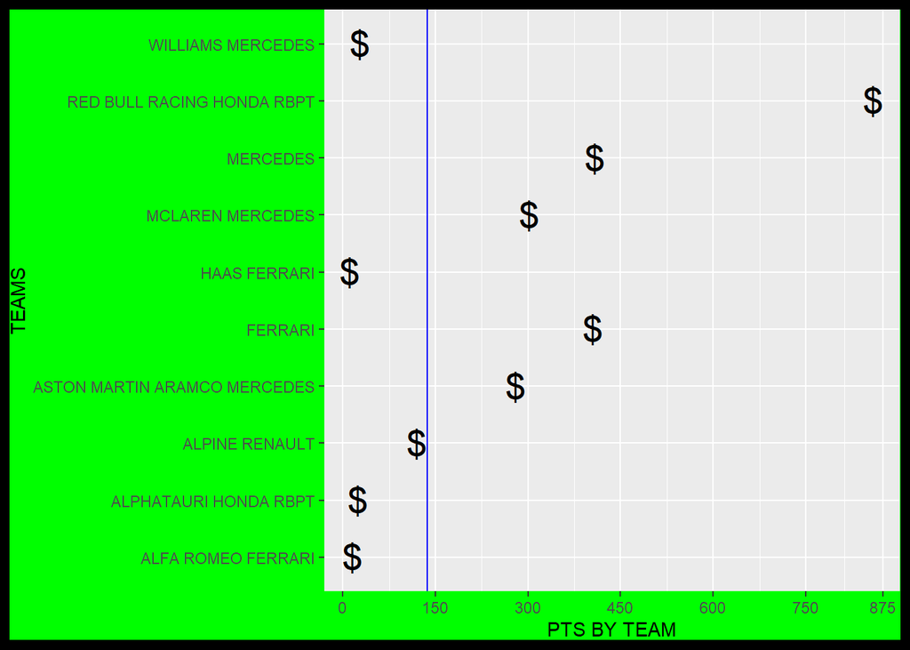

Wykres przedstawia wartość odchylenia standardowego w porównaniu ze zdobytymi PKT przez każdy zespół (niebieska linia przedstawia wartość policzonego odchylenia standardowego i wynosi ono ~136.99)

# 6 Pętla

```r
plik1 <- round(rnorm(50, 80, 80),0)
plik2 <- round(runif(50, 160, 190),0)
plik3 <- round(sample(c(40:110,NA,NA,NA,NA,NA),50,),0)

write.csv(plik1, "plik1.csv",row.names = F)
write.csv(plik2, "plik2.csv",row.names = F)
write.csv(plik3, "plik3.csv",row.names = F)
```

```r
pliki_w_katalogu <- list.files(path = "C:/Users/Pawel/Desktop/Studia 2023/R/Quarto", full.names = TRUE)
wynik <- tibble()
licznik_plikow <- 0
for (plik in pliki_w_katalogu) {
  if (licznik_plikow > 3) {
    stop("Nie możesz dodac wiecej niż 3 plikow")
  }
  else
  {
    if (file_ext(plik) == "csv") {
      dane3 <- read.csv(plik)
      wynik <- rbind(dane3, wynik)
      licznik_plikow = licznik_plikow + 1
    }
  }
}
tibble(wynik)
```

```
# A tibble: 150 × 1
       x
   <int>
 1    45
 2    85
 3    99
 4    72
 5    NA
 6    79
 7    75
 8    80
 9    NA
10    86
# ℹ 140 more rows
```

# 7 ggplot2

## 7.1 Wykres 1

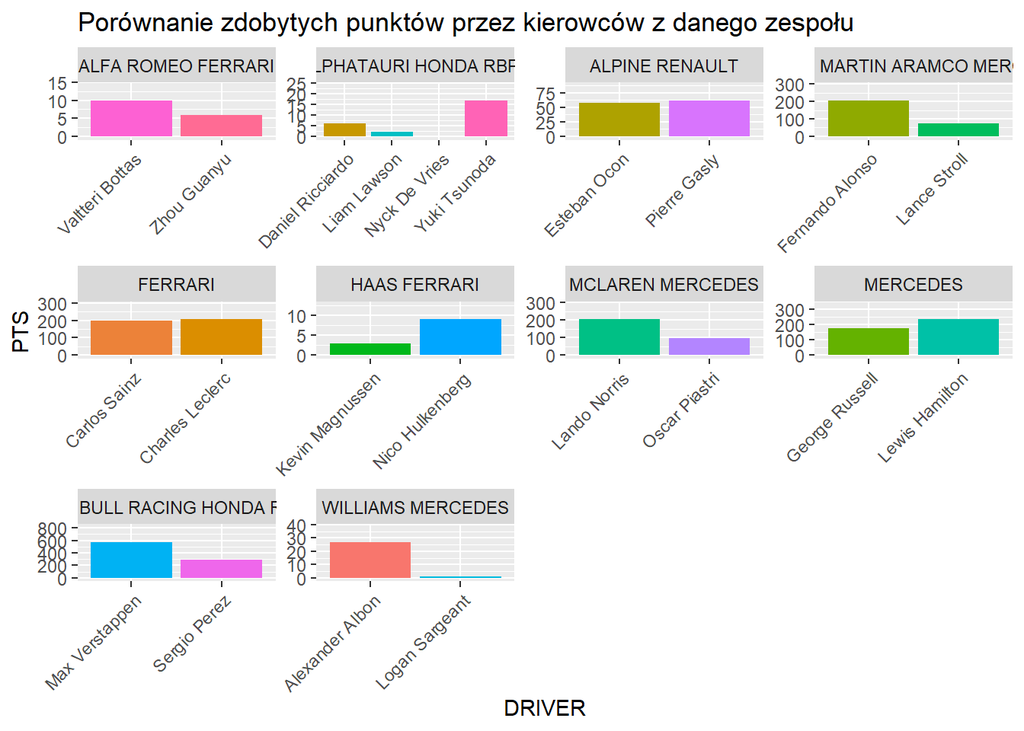

```r
data <- data.frame(
  DRIVER <- dane2$DRIVER,
  TEAM <- dane2$CAR,
  PTS <- dane2$PTS)
wykres1 <- ggplot(data, aes(x = DRIVER,y = PTS, fill = DRIVER)) +
  geom_bar(stat = "identity",show.legend = F,just = 0.5)+
  labs(title = "Porównanie zdobytych punktów przez kierowców z danego zespołu") +
  theme(axis.text.x = element_text(angle = 45, hjust = 1)) +
  facet_wrap(~data$TEAM, scales = "free") +
  scale_y_continuous(expand = expansion(mult = c(0.1, 0.5)))
wykres1
```

## 7.2 Wykres 2

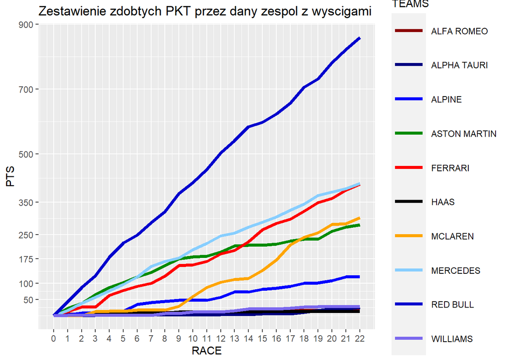

```r
wykres2 <-
dane_koncowe2 |>
ggplot(aes(RACE,value,colour = TEAMS))+
  geom_line(size = 1.5)+
  scale_color_manual(values = c("FERRARI" = "red", "RED BULL" = "blue3", "HAAS" = "black", "MCLAREN" = "orange", "ASTON MARTIN" = "green4","ALPINE" = "blue","ALPHA TAURI" = "navy","ALFA ROMEO" = "red4","MERCEDES" = "skyblue1","WILLIAMS" = "mediumslateblue"))+
  scale_x_continuous(breaks = c(0:22))+
  scale_y_continuous(breaks = c(50,100,175,250,350,500,700,900))+
  expand_limits(x = 0)+
  theme(legend.key.size = unit(1.2, "cm"))+
  labs(title = "Zestawienie zdobtych PKT przez dany zespol z wyscigami",
       y = "PTS")
wykres2
```